# Module 2G: Hedging Commodity Price Risk

# Learning Outcomes

By working on this module you should be able to

- Differentiate long and short positions in the market
- Explain the price risk facing those long and short in the market
- Describe a textbook example of a short and long hedge
- Explain how different marketing scenarios use hedging as a price risk reduction tool ***?
- Describe the Iowa corn and ethanol pricing data
- Explain how profits are earned given different scenarios, with and without hedging

# Overview of this Module

## Long and Short Positions in the Spot Market

A *short* position means you borrowed the commodity and immediately sold it, or something equivalent. You must eventually purchase the commodity and repay your loan. You benefit if the spot price falls, and you lose if the spot price rises.

## Textbook example of a short and long hedge

Figures 1 and 2 are some [textbook](http://simpson.ca.uky.edu/files/cme-self_study_guide_to_futures_and_options.pdf) examples of short and long hedge.

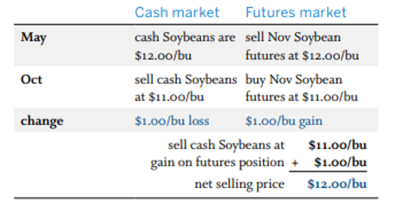

Figure 1: Short Hedge

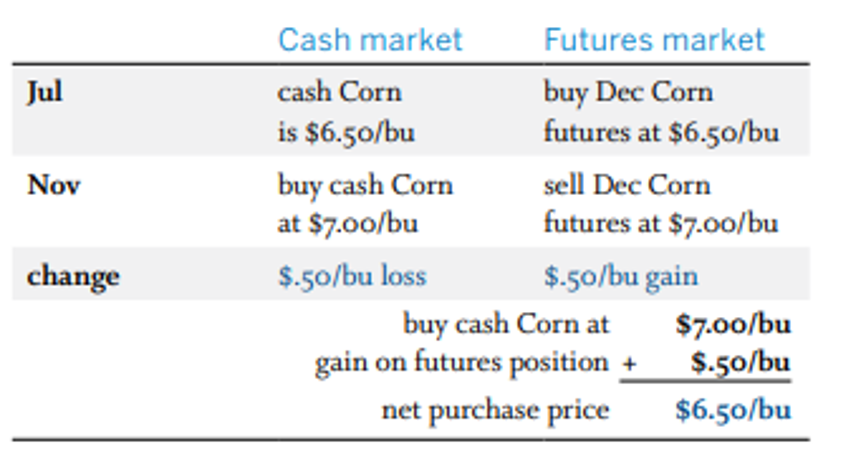

Figure 2: Long Hedge

# Case Study: Corn and Ethanol in Iowa

We now look at three distinct scenarios in Iowa for the years 2016-2021 to examine the degree to which hedging reduces price risk.

The [Mid Iowa Cooperative](https://www.midiowacoop.com/grains/cash-bids/) offers deferred delivery marketing contracts to local farmers. Figure 3 on the right shows the cash bids when the contract is signed on November 20, 2021 and the months the delivery is allowed. The second row shows that the delivery is allowed anytime in January 2022. The -$0.25/bu basis is added to the Nov 20<sup>th</sup> $5.77/bu March futures price to get the price paid to farmer at $5.52/bu, when the delivery is made.

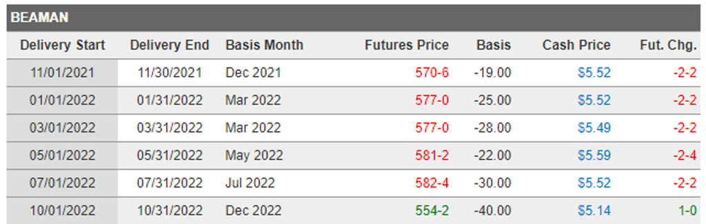

Figure 3: Corn Cash Bid, Beaman

# Forward Export Sales

The left panel of Figure 4 shows the aggregate export sales of US. corn as of November 11, 2021. Much of the “new sales” for the week of November 11, 2021 are forward sales by firms locking in a sales price; in the coming weeks, these firms will purchase the corn and initiate the delivery process. The right panel of Figure 4 shows a graph of U.S. corn export bids relative to those of other countries. Data sourced [here](https://apps.fas.usda.gov/psdonline/circulars/grain.pdf). Exporters of U.S. corn must aggressively use forward sales to be competitive. These forward sales put exporters in a short position in the spot market.

[figure not shown]

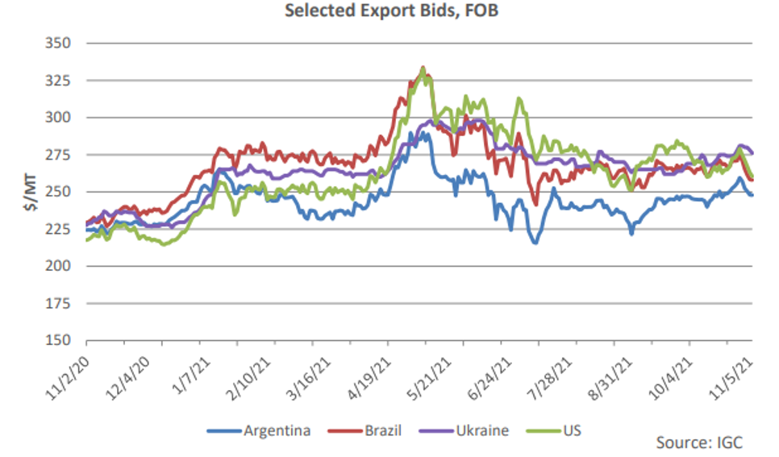

Figure 4: Forward Export Sales

## Case Study: Scenario 1

The first scenario we will look at is from the perspective of the Iowa Mid Cooperative who locks in a forward buy price with a local farmer. For example, referring to Figure 3, if the farmer signs a deferred contract on November 20<sup>th</sup> and agrees to deliver the price sometime in January 2022, the cooperative will pay the farmer $5.52/bu when the farmer makes delivery, regardless of the spot price that day. The cooperative then sells the delivered grain at the current market spot price. This agreement exposes the Iowa Mid Cooperative to risk because of price fluctuations, as you can see from Figure 5.

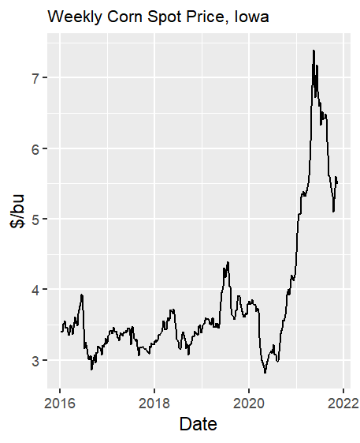

Figure 5: Weekly Corn Spot Price, Iowa

We first divide the weekly data into five groups:

- December, January, and February -> March Contract group
- March, April -> May Contract group
- May, June -> July Contract group
- July, August -> September Contract group
- September, October, November -> December contract group

This sub division ensures that when we later examine hedging scenarios, the forward contract and the delivery of the commodity take place in the same basis month. For example, a forward purchase in mid December and delivery in early February take place when the basis is calculated with the March contract.

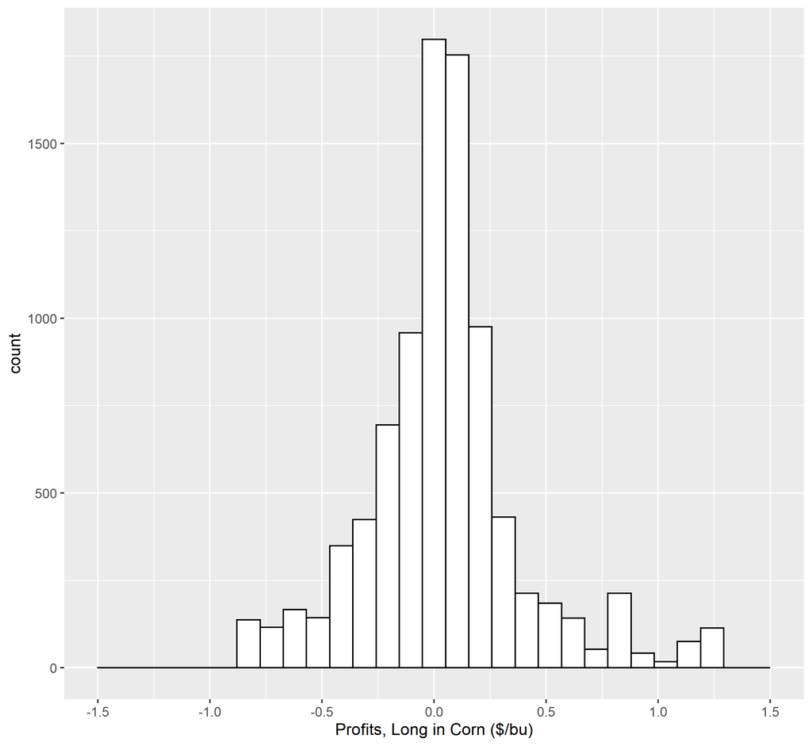

Figure 6: Profits, Long in Corn ($/bu)

The price risk facing the cooperative who is long in the Iowa corn spot market for an average duration of 2.8 weeks is reflected by the left tail of the histogram. The following percentiles quantify this risk.

|  | 5% | 10% | 20% | 30% | 40% | 50% |
| --- | --- | --- | --- | --- | --- | --- |
| Long Spot | -0.56 | -0.38 | -0.18 | -0.08 | -0.02 | 0.04 |

We can interpret the percentiles as follows. The cooperative faces a 5% probability of losing more than $0.56/bu. The cooperative faces a 10% probability of losing between $0.18 and $0.38/bu. The cooperative earns around $0.04/bu on average but there is a sizeable price risk.

To hedge against falling prices, the cooperative should:

- Take a short position when the deferred delivery contract is signed.
- Offset the short position when the farmer delivers the commodity and the cooperative sells it in the spot market.

Losses on the spot market transaction are partially offset by gains in the futures market and vice versa. The same simulation procedure is used to generate 9000 occurences of combined spot market and future market profit outcomes. Figure 7 shows the histogram of these profit outcomes.

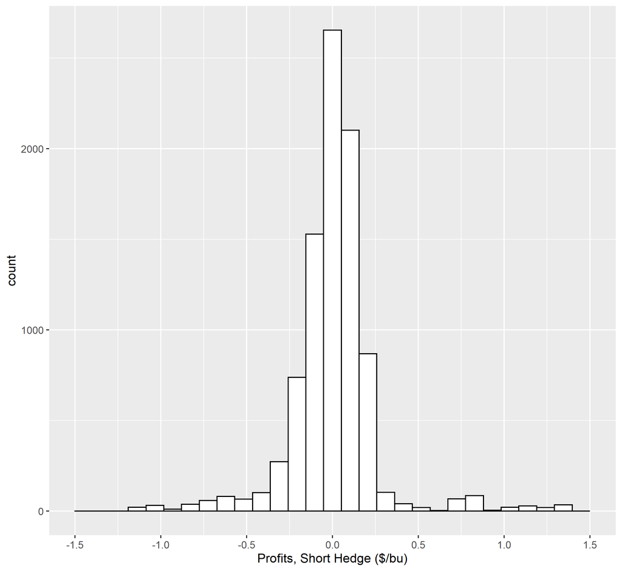

Figure 7: Profits, Short Hedge ($/bu)

You can see that Figure 7 has much thinner tails compared to Figure 6. The thinning of the left tail implies significantly lower risk. A comparison of the percentiles quantifies the difference in risk. The short hedge has signfiicantly reduced price risk in the left tail of the distribution.

|  | 5% | 10% | 20% | 30% | 40% | 50% |
| --- | --- | --- | --- | --- | --- | --- |
| Long Spot | -0.56 | -0.38 | -0.18 | -0.08 | -0.02 | 0.04 |
| Short Hedge | -0.32 | -0.23 | -0.13 | -0.06 | -0.02 | 0.01 |

In Figure 8, we plot plot two profit histograms on one chart to better see the reduction in price risk. The red bars represent the profit distribution when the cooperative takes a long spot position. The blue bars represent the profit distribution when the cooperative tatkes a short hedge. The purple bars are the overlap between the profits in the long spot and short hedge positions. We can see that the the blue bars (short hedge) are lower than the red bars (long spot) at the tails, meaning there is less risk. Note that the hedge does not completely eliminate the risk.

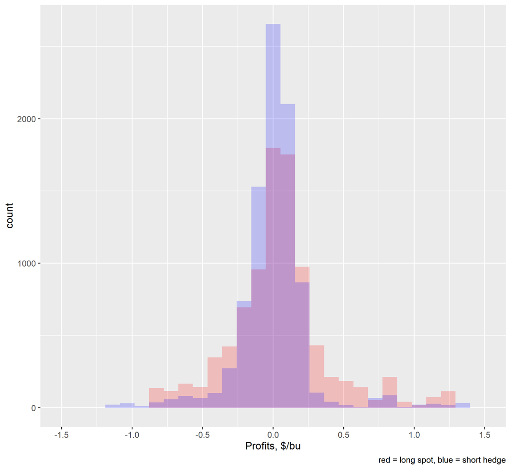

Figure 8: Profits, Long Spot and Short Hedge ($/bu)

Figure 9

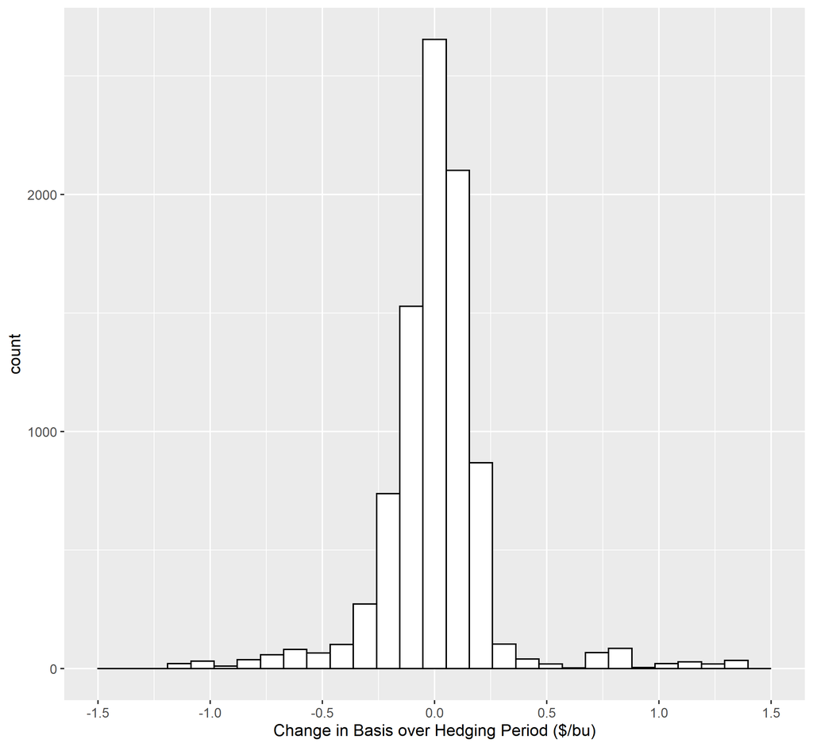

Figure 9: Change in Basis over Hedging Period($/bu)

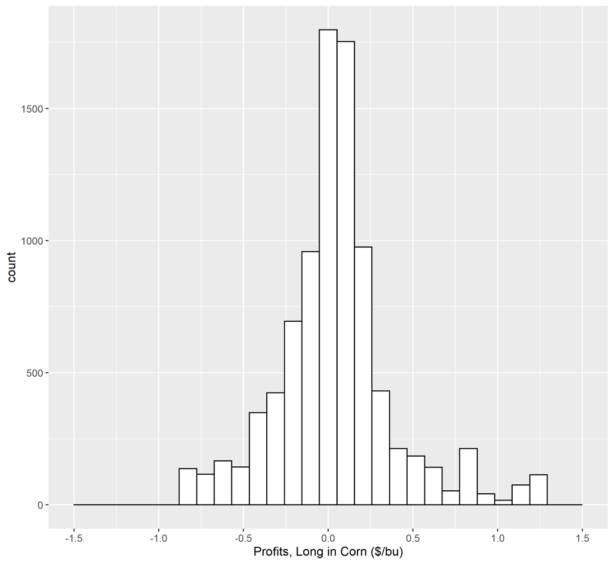

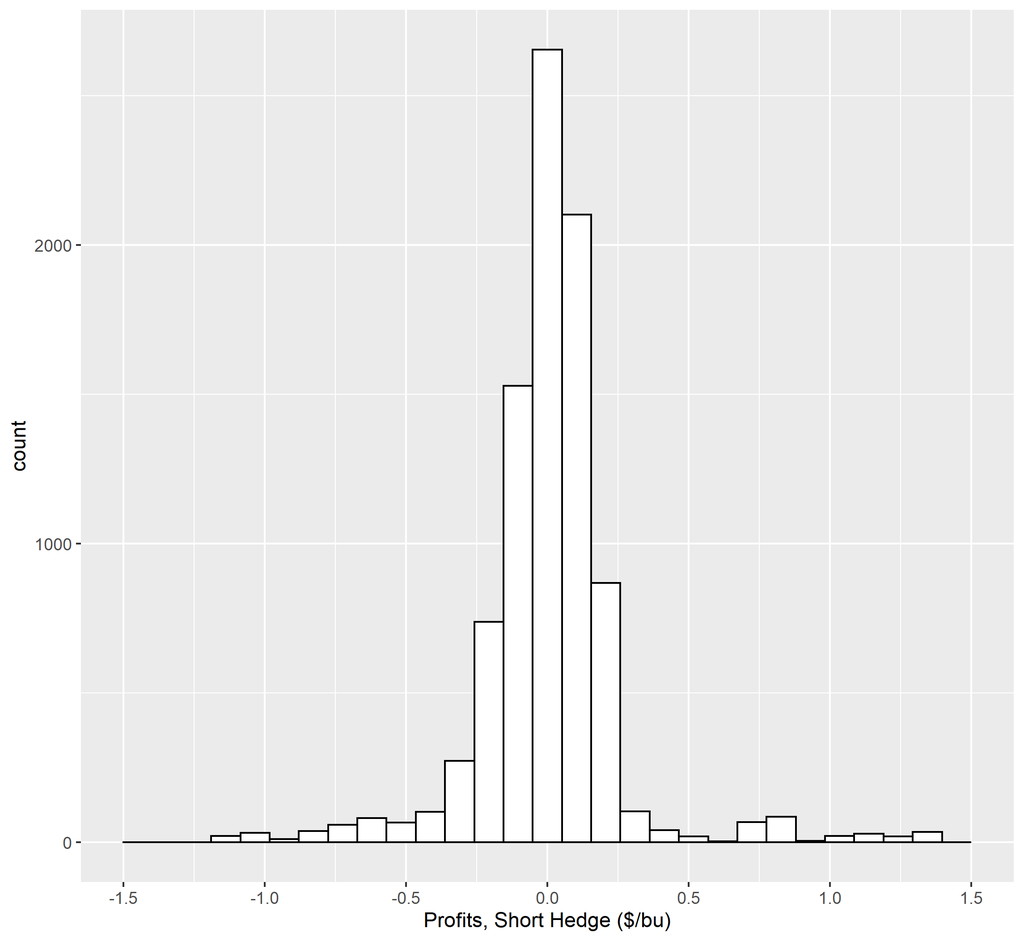

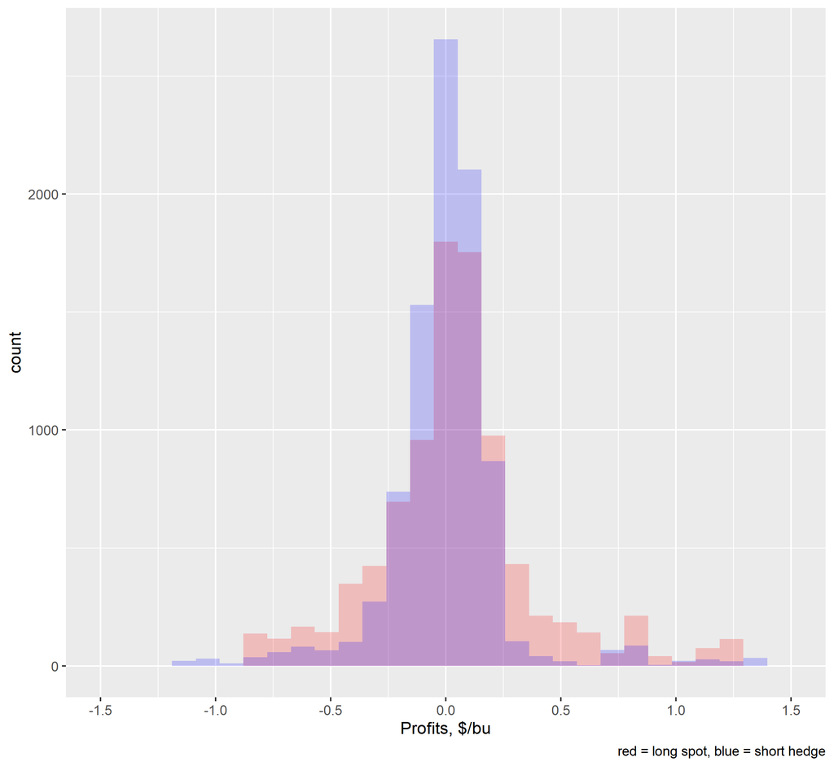

Figure 10: Profits - Long Spot, Short Hedge, Overlay ($/bu)

## Case Study: Scenario 2

Optimal Hedging Ratio

High Correlation but Different Std Dev

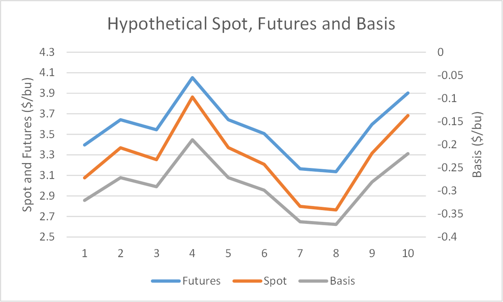

Figure 11: Hypothetical Spot, Futures, Basis

## Case Study: Scenario 3

We now examine three scenarios

The weekly data is an aggregate for Iow, as reported in [here](https://www.extension.iastate.edu/agdm/energy/xls/agmrcethanolplantprices.xlsx). The spot price for corn was derived by adding the Iowa’s corn basis, as reported by the USDA, to the prcie of the closest CME corn contract. The spot price of ethanol was derived by adding the Iowa’s ethanol basis as reported by the USDA, to the price of the closest CME ethanol contract. The price of DDG (dried distillers grains) are based on feedlot payments. Of particular interest is the strength of the correlation between raw corn and DDG because both are highly substitutable as a livestock feed. The correlation between corn and DDG is approximately 0.75, which is relatively strong but still far from reflecting perfect substitutability.

In the first scenario, the cooperative locks in a forward buy price with the farmer. When the farmer delivers the corn in a months time, the cooperative sells it at the current market spot price. Figure Figure 12 shows the spot prices of DDG, Ethanol, and Corn.

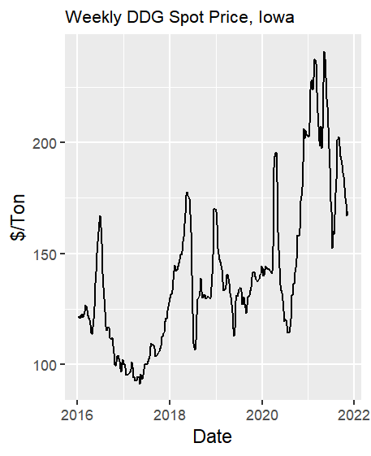

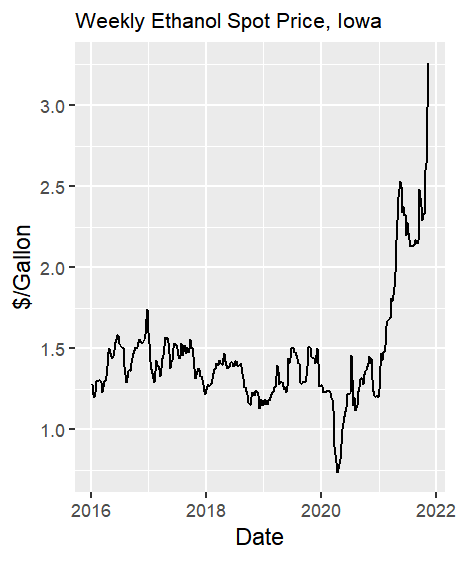

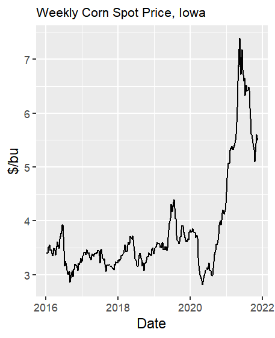

Figure 12: Spot Prices - DDG, Ethanol, and Corn

Figure 13 shows the revenue and cost in ethanol production. The blue line represents the sale of ethanol and DDG, and the red line represent the purchase of corn. The gap between these two lines is called the *crush margin* if all pricing is on the same day. One can also trade on the crush margin. **Read about the soybean crush [here](https://www.cmegroup.com/education/courses/introduction-to-agriculture/grains-oilseeds/understanding-soybean-crush.html) and check sobyean crush prices [here](https://www.barchart.com/futures/quotes/CS*0/futures-prices).**

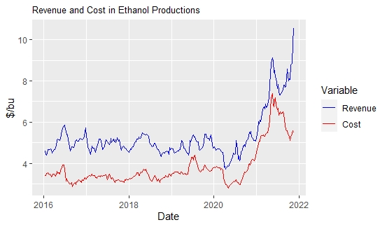

Figure 13: Revenue and Cost in Ethanol Production

Figure 14

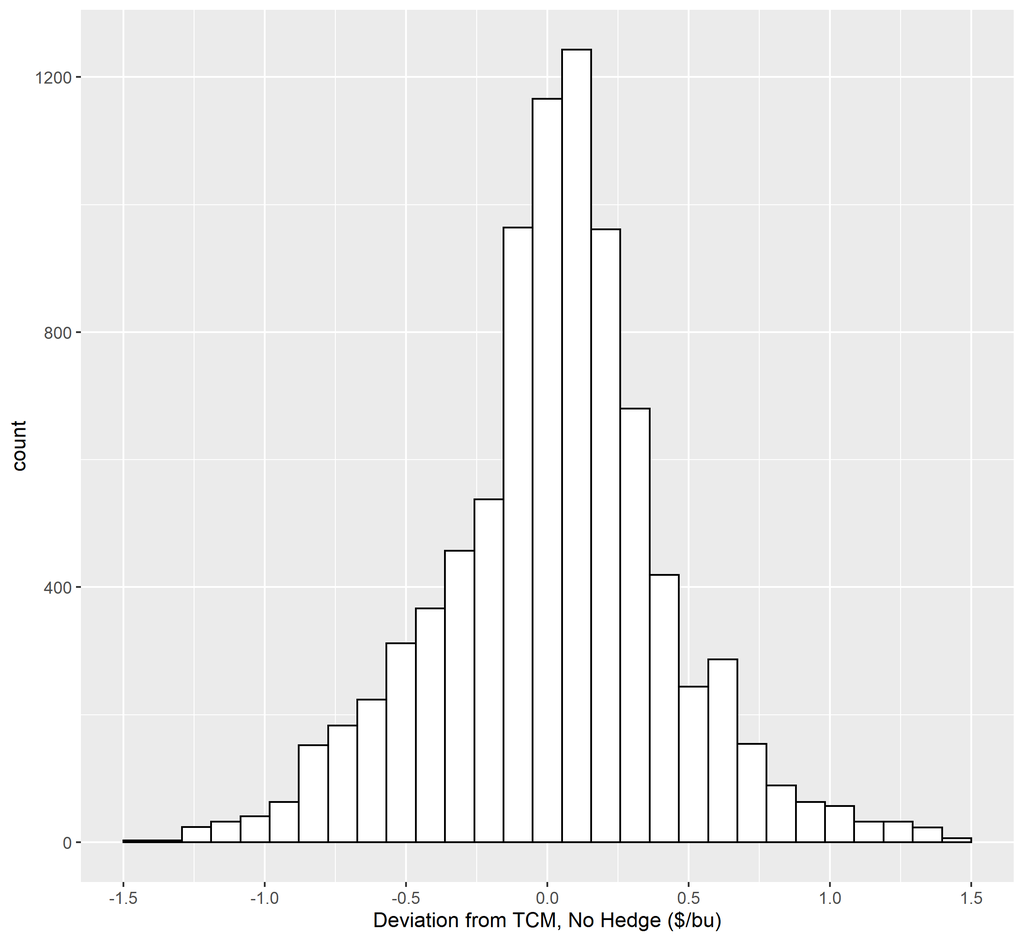

Figure 14: Deviation from TCM, No Hedge ($/bu)

Figure 15

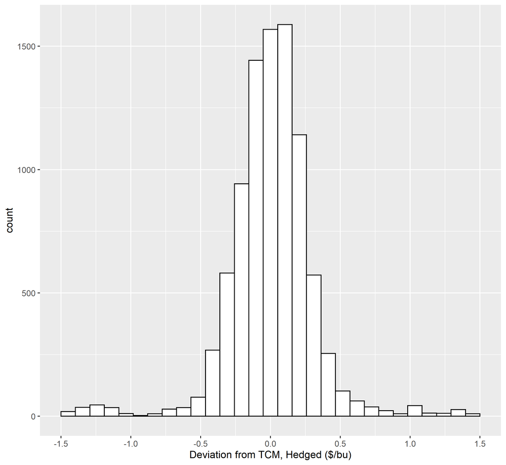

Figure 15: Deviation from TCM, Hedge ($/bu)

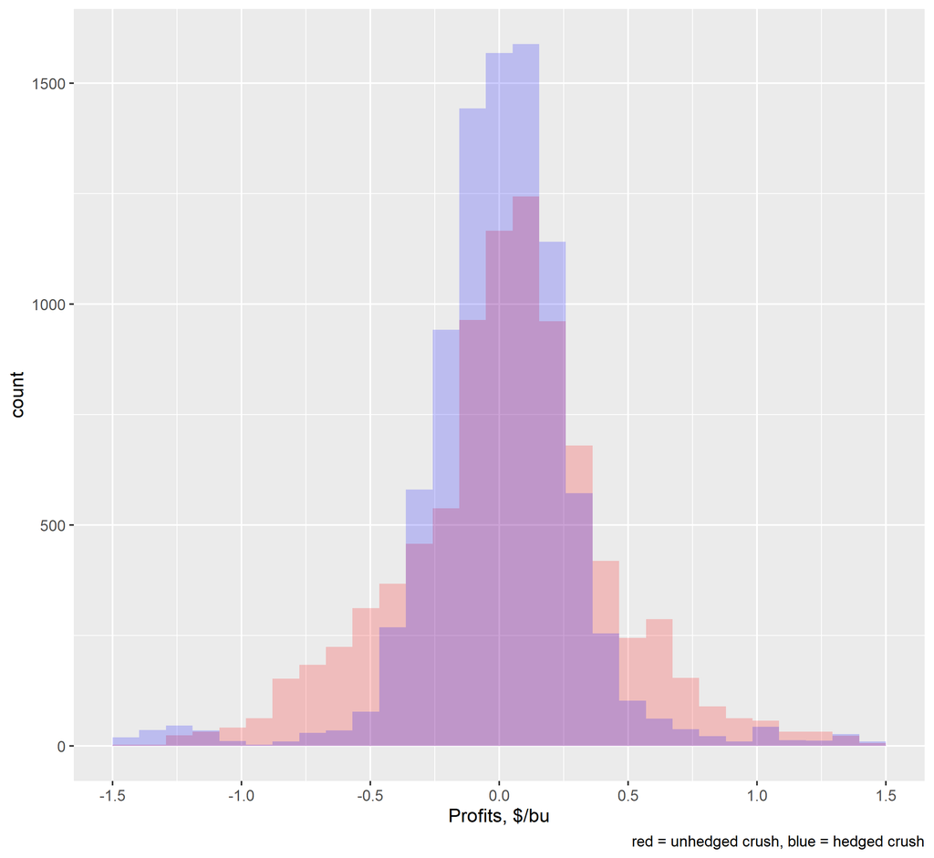

Figure 16: Deviation from TCM, No Hedge and Hedged ($/bu)

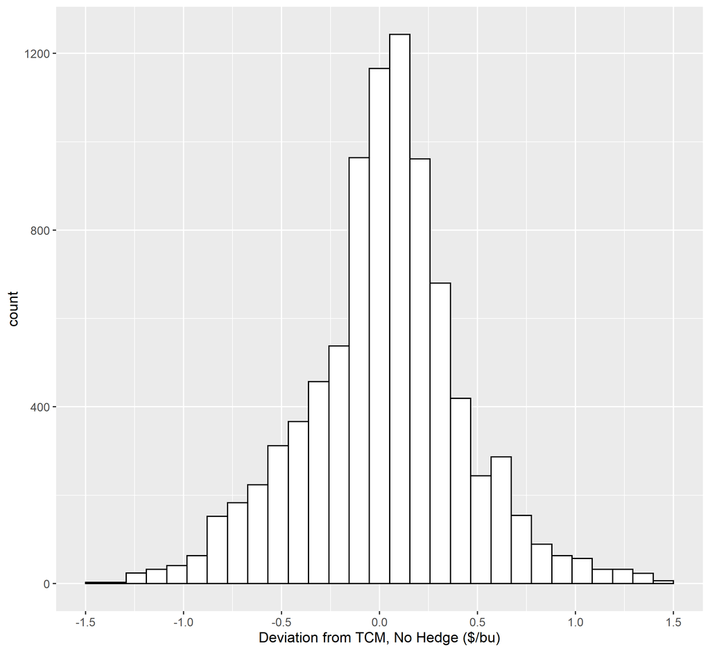

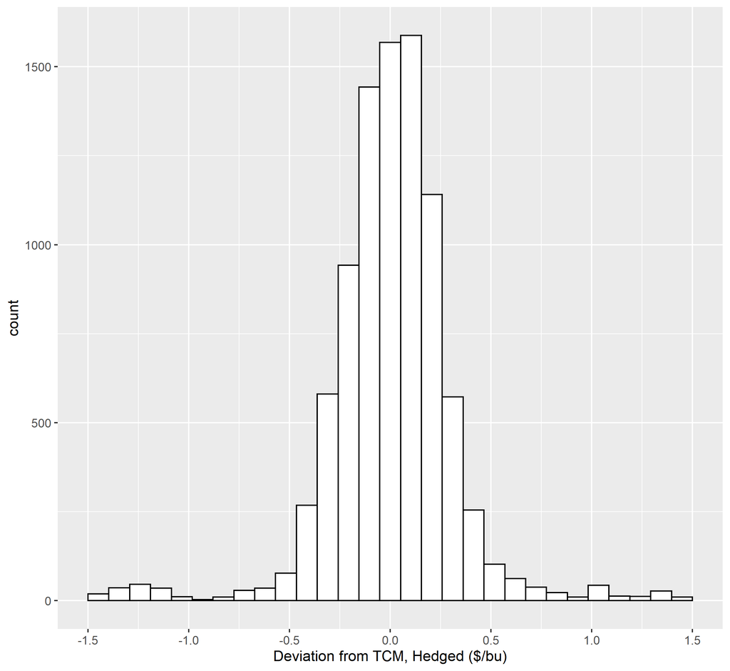

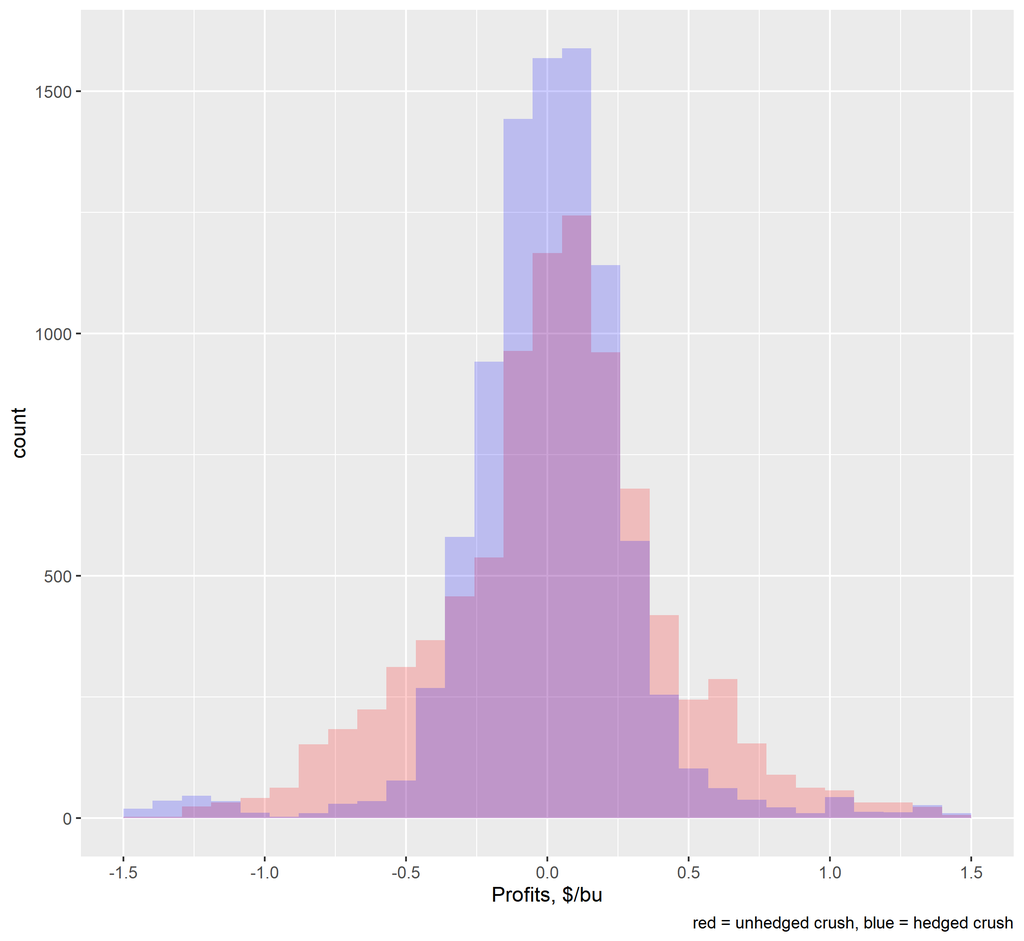

Figure 17: Deviation from TCM - No Hedge, Hedged, Overlay ($/bu)

# Part B

## Short Hedging Profits

$(\tilde{P}_1 - P_0) + (F_0 - \tilde{F}_1)$

## Short Hedge with Farm Delivery at Date 0

Let $\tilde\omega_{0,1}$ be the carrying cost between dates 0 and 1, and let $\tilde\pi_{S}$ denote net short hedging profits for the cooperative.

$$\tilde\pi_{S} = (\tilde{P}_1 - P_0) + (F_0 - \tilde{F}_1) - \tilde\omega_{0,1}$$

Rearranging the equation above, we get

$$\tilde\pi_{S} = (\tilde{P}_1 - \tilde{F}_1) - (P_0 - F_0) - \tilde\omega_{0,1}$$
We can rewrite the above equation as $\tilde\pi_{S} = \tilde{B}_1 - B_0 - \tilde\omega_{0,1}$

Figure 18 shows that when the market is in equilibrium, the short hedger expects zero profits from the hedge.

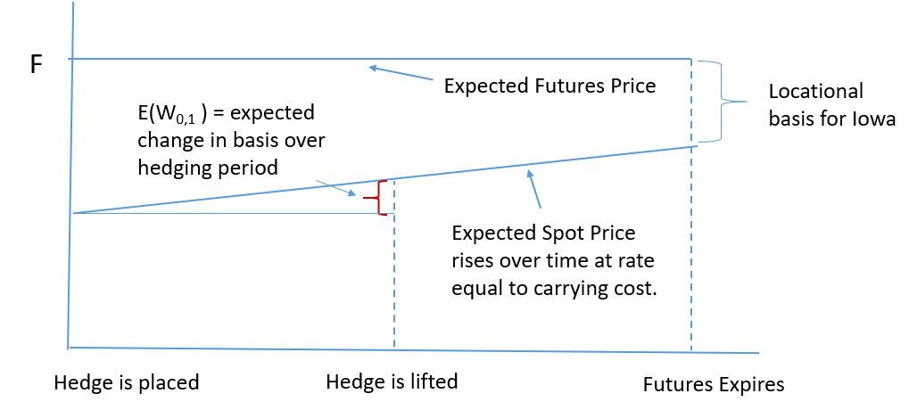

Since $E(B_1-B_0) = E(\omega_{0,1})$ we can conclude that $E(\hat\pi_S) = E(B_1 - B_0 - \omega_{0,1})$

## Short Hedge with Farm Delivery at Date T

In this case the farmer will incur the carrying cost over the hedging period of $\tilde\omega_{0,1}$.

If $P_0$ is not adjusted then the carrying cost savings for the cooperative translate into positive profits for the cooperative.

Competition may force the cooperative to set the contract price equal to $P_0 + E(\tilde\omega_{0,1})$ in which case the farmer’s carrying cost is covered by the higher price, and the cooperative expects zero profits.

## Corn Exporter Long Hedge

At date 0, an exporter forward sells corn at Price $P_0$ and hedges with a long futures position at price $F_0$. At date 1, the exporter purchases the corn at price $\tilde{P}_1$ and offsets with a long hedge at price $\tilde{F}_1$. Exporter expects the spot price to rise between dates 0 and 1 by an amount equal to the market’s expected carrying cost, $E(\tilde\omega_{0,1})$. Exporter adds $E(\tilde\omega_{0,1})$ to $P_0$ to ensure it will break even on the transaction.

Profits for the long hedger equal

$$\tilde\pi_L = P_0 + E(\tilde\omega_{0,1}) - \tilde{P}_1 + (\tilde{F}_1 - F_0)$$

Rearranging this equation as

$$\tilde\pi_L = -[\tilde{P}_1 - \tilde{F}_1 - (P_0 - F_0) - E(\tilde\omega_{0,1})]$$

Notice that this equation can be rewritten as

$$\tilde\pi_L = -[\tilde{B}_1 - B_0 - E(\tilde\omega_{0,1})]$$
Profits for the long hedger are equal to the profits for the short hedger but with the opposite sign.

Note that $E(\tilde\pi_L) = 0$ since $E(\tilde{B}_1 - \tilde{B}_0) = E(\tilde\omega_{0,1})$

## Hedging with a Strong Basis

The equilibrium basis at date 0 is $E(L_T) - E(\tilde\omega_{0, T})$ where $E(L_T)$ is the expected location component of the basis at futures expiry at date T.

Suppose that due to a regional demand surge, the date 0 basis is equal to $-E(L_T) - E(\tilde\omega_{0, T}) + \delta$ -> the basis is strong compared to equlibrium

The basis is expected to equal $-E(L_T)$ at date T

These two results together imply the basis will increase at a rate which is slower than the equilibrium rate of increase.

The slower increase implies less strengthening of the basis over the hedging period -> Lower profits for short hedger and higher profits for long hedger.

Figure 19 shows that expected hedging profits are lower for the short hedger and higher for the long hedger if the initial basis is strong.

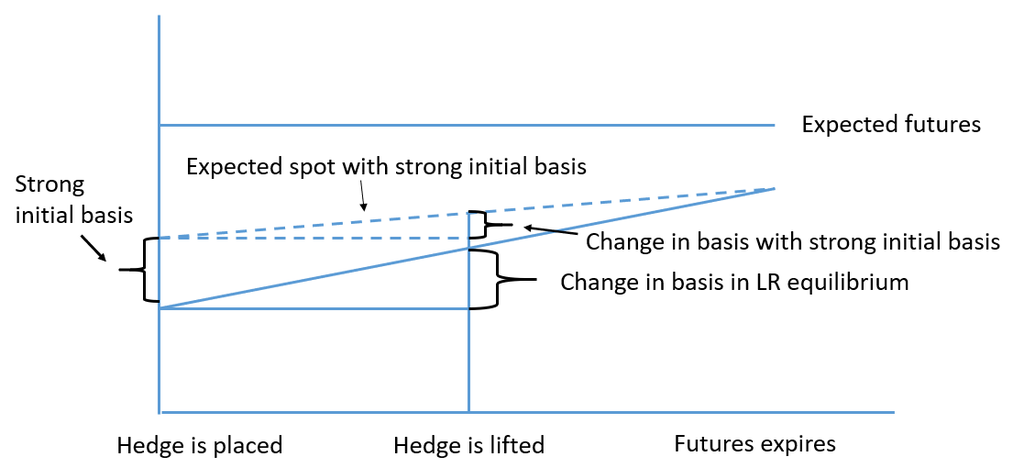

## Change in Basis After Hedge is Placed

## Hedging the Crush Margin: Simple Case

The target crush margin is $M_0 = 2.8P^{E}_0 + 0.0085P_0^{D} - P_0^{C}$.

The actual crush margin is $\tilde{M}_1 = 2.8\tilde{P}^{E}_0 + 0.0085P_0^{D} - \tilde{P}_0^{C}$.

Let $\Delta_{C}$ be the deviation of the actual crush from the target crush.

Let $\Delta_{C} = 2.8(\tilde{P}_1^E - P_0^E) - (\tilde{P}_1^C - P_0^C)$

Let $\Delta$ be the deviation of the actual crush from the target crush inclusive of gains/losses in the futures market.

$$\Delta = 2.8(\tilde{P}_1^E - P_0^E) - (\tilde{P}_1^C - P_0^C) + (\tilde{F}_1^C - F_0^C) - 2.8(\tilde{F}_1^E - F_0^E)$$

Rewrite as

$$\Delta = 2.8[(\tilde{P}_1^E - \tilde{F}_1^E ) - (\tilde{P}_0^E - F_0^E)] - [(\tilde{P}_1^{C} - \tilde{F}_1^{C}) - (P_0^C - F_0^C)]$$

The net deviation of the crush margin from the target is the difference in how the ethanol and corn basis changes over the hedging period.

## Review of Eight Quarter Model Results

In [Module 2D](https://vercammen.github.io/module2d.html), we introduced a price matrix that comes from 5000 sets of simulated spot and futures prices from an econometrics analysis of the USDA crop production and WASDE monthly forecasts. The top row is the base case set of equilibrium prices for Q1. The second row is the new set of prices after the revised forecasts arrive and the model is resolved for a new set of prices. The $i^{th}$ column shows how prices for that particular time period are updated given the revised forecast. (The matrix below appears in p.20 of your November 20 lecture slides.) We use this matrix to help us analyze how a change in USDA forecasted demand for Q8 stocks affects short and long hedging profits.

```r
prices <- readRDS(here("Data", "prices_8.RDS"))
prices
```

```
##           pQ1      pQ2      pQ3      pQ4      pQ5       pQ6      pQ7       pQ8
## [1,] 3.490479 3.653214 3.708320 3.656269 3.496614 3.6592973 3.714403 3.6624041
## [2,]       NA 1.654043 1.692013 1.605544 1.393893 1.5875896 1.655951 1.5995640
## [3,]       NA       NA 1.904201 1.819550 1.611552 1.8115652 1.888163 1.8420023
## [4,]       NA       NA       NA 1.345151 1.133087 1.3388094 1.417064 1.3685229
## [5,]       NA       NA       NA       NA 1.021511 1.2184257 1.286842 1.2273447
## [6,]       NA       NA       NA       NA       NA 0.9030087 0.968721 0.9037938
## [7,]       NA       NA       NA       NA       NA        NA 1.098349 1.0345325
## [8,]       NA       NA       NA       NA       NA        NA       NA 1.5031297
```

Recall that the prices on the first row are the base case (non-stochastic) prices. The elements on the diagonal are spot prices and prices to the right of the diagonal are futures prices. One contract expires each quarter. This means that in the top row, the price in the pQ1 column (i.e., 3.49) minus the price in the pQ7 column (i.e., 3.714) is the basis for a Q7 contract when in Q1. So, when the demand forecast did not change, then moving through time, the spot prices would equal the values in the top row.

The vector below shows the saw toothed seasonal basis with base case calculation.

```r
s_basis <- prices[1,1:7] - prices[1,7]
s_basis
```

```
##          pQ1          pQ2          pQ3          pQ4          pQ5          pQ6
## -0.223924740 -0.061189210 -0.006083273 -0.058134593 -0.217789325 -0.055105937
##          pQ7
##  0.000000000
```

```r
# both methods are the same
# rounding makes the answers different from the slides
net_basis <- diag(prices[1:7,]) -  prices[1:7,7] - s_basis
net_basis
```

```
##         pQ1         pQ2         pQ3         pQ4         pQ5         pQ6
##  0.00000000  0.05928115  0.02212103 -0.01377885 -0.04754170 -0.01060640
##         pQ7
##  0.00000000
```

```r
net_basis_manual <- c()
net_basis_manual[1] <- prices[1,1] - prices[1,7] - s_basis[1]
net_basis_manual[2] <- prices[2,2] - prices[2,7] - s_basis[2]
net_basis_manual[3] <- prices[3,3] - prices[3,7] - s_basis[3]
net_basis_manual[4] <- prices[4,4] - prices[4,7] - s_basis[4]
net_basis_manual[5] <- prices[5,5] - prices[5,7] - s_basis[5]
net_basis_manual[6] <- prices[6,6] - prices[6,7] - s_basis[6]
net_basis_manual[7] <- prices[7,7] - prices[7,7] - s_basis[7]
print(round(net_basis_manual, 5))
```

```
## [1]  0.00000  0.05928  0.02212 -0.01378 -0.04754 -0.01061  0.00000
```

# Appendix - Simulations

```r
data <- read.csv(here("Data", "corn_ethanol_data.csv"), header=TRUE, sep=",", stringsAsFactors = FALSE)

# convert Week to date format
data$Week <- as.Date(data$Week, format = c("%m/%d/%Y"))

# setting the seed will ensure we can reproduce the random result
set.seed(2021)

compare_repeat = list() # create the list which will hold the results to be saved

for (j in 1:300) {
for (i in 1:30) {
  sample <- data[sample(which(data$Index == i ), 3),] # random select three rows for each of 30 index values
  sample <- sample[order(sample$Week),] # order from oldest to newest
  sample <- as.data.frame(sample)
# construct single row which combines dates and prices from three rows.
  Date1 <- sample$Week[1]
  Date2 <- sample$Week[2]
  Date3 <- sample$Week[3]
  DDG1 <- sample$DDG[1] # choose this and next four prices from first row
  Corn1 <- sample$CornSpot[1]
  Ethanol1 <- sample$Ethanol[1]
  FutCorn1 <- sample$CornFut[1]
  FutEthan1 <- sample$EthanFut[1]
  Corn2 <- sample$CornSpot[2] # choose this and next two prices from second row
  FutCorn2 <- sample$CornFut[2]
  FutEthan2 <- sample$EthanFut[2]
  Corn3 <- sample$CornSpot[3] # choose this and next three prices from third row
  FutCorn3 <- sample$CornFut[3]
  Ethanol3 <- sample$Ethanol[3]
  FutEthan3 <- sample$EthanFut[3]
  # bind previous variables into a single row
  # data.frame() instead of cbind() ensures date formats are preserved
  sample3 <- data.frame(Date1, Date2, Date3, DDG1,Corn1,Ethanol1,FutCorn1,FutEthan1,Corn2,FutCorn2,Corn3,FutCorn3,Ethanol3,FutEthan3)

  # Construct the specific measures of hedging profits
  # Long in corn with no hedge: long_corn <- Buy corn[1] and sell corn[3]
  # Short in corn with no hedge: short_corn <- Sell corn[1] and buy corn[3]
  # Crush margin: crushNH <- Sell DDG[1], buy corn[2] and sell ethanol[3]
  # Short hedge: short_hedge <- Buy corn[1], short corn futures[1], sell corn[3] and long corn futures[3]
  # Long hedge: long_hedge <- Sell corn[1], long corn futures[1], buy corn[3] and short corn futures[3]
  # Crush hedge: crushH <- Sell DDG[1], long corn futures[1], short ethanol futures[1], buy corn[2], sell corn futures[2], sell ethanol[3] and long ethanol futures[3]

  compare <- sample3 %>% mutate(
    long_corn = -Corn1 + Corn3,
    short_corn = Corn1 - Corn3,
    crush1 = 0.0085*DDG1+2.8*Ethanol1-Corn1,
    crushNH = 0.0085*DDG1+2.8*Ethanol3-Corn2 - crush1,
    short_hedge = -Corn1 + Corn3 + FutCorn1/100 - FutCorn3/100,
    long_hedge = Corn1 - Corn3 - FutCorn1/100 + FutCorn3/100,
    crushH =  0.0085*DDG1+2.8*Ethanol3-Corn2 + 2.8*FutEthan1 - FutCorn1/100 + FutCorn2/100 - 2.8*FutEthan3 - crush1,
    cornBasis1 = Corn1 - FutCorn1/100,
    cornBasis2 = Corn2 - FutCorn2/100,
    cornBasis3 = Corn3 - FutCorn3/100,
    ethanolBasis1 = Ethanol1 - FutEthan1,
    ethanolBasis3 = Ethanol3 - FutEthan3,
    BasisChange = cornBasis3 - cornBasis1) %>%
    select(Date1, Date2, Date3, long_corn,short_corn,crushNH,short_hedge,long_hedge,crushH,cornBasis1,cornBasis2,cornBasis3,ethanolBasis1,ethanolBasis3, BasisChange)

  compare_repeat[[(j-1)*35+i]] <- compare
}
}

compare_full <- dplyr::bind_rows(compare_repeat)
```